# Data Exploration: Candy Study Dataset

#Load libraries

```r
# Libraries need to be installed before they can be used (but only once)

#install.packages("magrittr")
#install.packages("plyr")
#install.packages("dplyr")
#install.packages("ggplot2")
#install.packages("grid")
#install.packages("gridExtra")
#install.packages("stringr")
#install.packages("reshape2")


#STRG+SHIFT+RETURN
# load already installed libraries
library(magrittr)
library(plyr)
library(dplyr)
library(ggplot2)
library(grid)
library(gridExtra)
library(stringr)
library(here)
library(scales)
library(readr)
library(tidyverse)
library(tibble)
library(reshape2)
```

#Data Beschreibung

[Source](https://github.com/fivethirtyeight/data/blob/master/candy-power-ranking/candy-data.csv) Header Description -chocolate: Does it contain chocolate? -fruity : Is it fruit flavored? -caramel: Is there caramel in the candy? -peanutalmondy: Does it contain peanuts, peanut butter or almonds? -nougat: Does it contain nougat? -crispedricewafer: Does it contain crisped rice, wafers, or a cookie component? -hard: Is it a hard candy? -bar: Is it a candy bar? -pluribus: Is it one of many candies in a bag or box? -sugarpercent: The percentile of sugar it falls under within the data set. -pricepercent: The unit price percentile compared to the rest of the set. -winpercent: The overall win percentage according to 269,000 matchups.

##upload Data

```r
url <- "https://raw.githubusercontent.com/fivethirtyeight/data/master/candy-power-ranking/candy-data.csv"

# Read the CSV data into a data frame
candy_raw <- read.csv(url)
```

# Descriptive Statistics

```r
head(candy_raw)
```

|  | competitorname | chocolate | fruity | caramel | peanutyalmondy | nougat | crispedricewafer | hard | bar | pluribus | sugarpercent | pricepercent | winpercent |
| --- | --- | --- | --- | --- | --- | --- | --- | --- | --- | --- | --- | --- | --- |
| 1 | 100 Grand | 1 | 0 | 1 | 0 | 0 | 1 | 0 | 1 | 0 | 0.732 | 0.860 | 66.97173 |
| 2 | 3 Musketeers | 1 | 0 | 0 | 0 | 1 | 0 | 0 | 1 | 0 | 0.604 | 0.511 | 67.60294 |
| 3 | One dime | 0 | 0 | 0 | 0 | 0 | 0 | 0 | 0 | 0 | 0.011 | 0.116 | 32.26109 |
| 4 | One quarter | 0 | 0 | 0 | 0 | 0 | 0 | 0 | 0 | 0 | 0.011 | 0.511 | 46.11650 |
| 5 | Air Heads | 0 | 1 | 0 | 0 | 0 | 0 | 0 | 0 | 0 | 0.906 | 0.511 | 52.34146 |
| 6 | Almond Joy | 1 | 0 | 0 | 1 | 0 | 0 | 0 | 1 | 0 | 0.465 | 0.767 | 50.34755 |

#Show structure information about the dataframe.

```r
str(candy_raw)
```

```
## 'data.frame':    85 obs. of  13 variables:
##  $ competitorname  : chr  "100 Grand" "3 Musketeers" "One dime" "One quarter" ...
##  $ chocolate       : int  1 1 0 0 0 1 1 0 0 0 ...
##  $ fruity          : int  0 0 0 0 1 0 0 0 0 1 ...
##  $ caramel         : int  1 0 0 0 0 0 1 0 0 1 ...
##  $ peanutyalmondy  : int  0 0 0 0 0 1 1 1 0 0 ...
##  $ nougat          : int  0 1 0 0 0 0 1 0 0 0 ...
##  $ crispedricewafer: int  1 0 0 0 0 0 0 0 0 0 ...
##  $ hard            : int  0 0 0 0 0 0 0 0 0 0 ...
##  $ bar             : int  1 1 0 0 0 1 1 0 0 0 ...
##  $ pluribus        : int  0 0 0 0 0 0 0 1 1 0 ...
##  $ sugarpercent    : num  0.732 0.604 0.011 0.011 0.906 ...
##  $ pricepercent    : num  0.86 0.511 0.116 0.511 0.511 ...
##  $ winpercent      : num  67 67.6 32.3 46.1 52.3 ...
```

#Show summary statistics per column.

```r
summary(candy_raw)
```

```
##  competitorname       chocolate          fruity          caramel
##  Length:85          Min.   :0.0000   Min.   :0.0000   Min.   :0.0000
##  Class :character   1st Qu.:0.0000   1st Qu.:0.0000   1st Qu.:0.0000
##  Mode  :character   Median :0.0000   Median :0.0000   Median :0.0000
##                     Mean   :0.4353   Mean   :0.4471   Mean   :0.1647
##                     3rd Qu.:1.0000   3rd Qu.:1.0000   3rd Qu.:0.0000
##                     Max.   :1.0000   Max.   :1.0000   Max.   :1.0000
##  peanutyalmondy       nougat        crispedricewafer       hard
##  Min.   :0.0000   Min.   :0.00000   Min.   :0.00000   Min.   :0.0000
##  1st Qu.:0.0000   1st Qu.:0.00000   1st Qu.:0.00000   1st Qu.:0.0000
##  Median :0.0000   Median :0.00000   Median :0.00000   Median :0.0000
##  Mean   :0.1647   Mean   :0.08235   Mean   :0.08235   Mean   :0.1765
##  3rd Qu.:0.0000   3rd Qu.:0.00000   3rd Qu.:0.00000   3rd Qu.:0.0000
##  Max.   :1.0000   Max.   :1.00000   Max.   :1.00000   Max.   :1.0000
##       bar            pluribus       sugarpercent     pricepercent
##  Min.   :0.0000   Min.   :0.0000   Min.   :0.0110   Min.   :0.0110
##  1st Qu.:0.0000   1st Qu.:0.0000   1st Qu.:0.2200   1st Qu.:0.2550
##  Median :0.0000   Median :1.0000   Median :0.4650   Median :0.4650
##  Mean   :0.2471   Mean   :0.5176   Mean   :0.4786   Mean   :0.4689
##  3rd Qu.:0.0000   3rd Qu.:1.0000   3rd Qu.:0.7320   3rd Qu.:0.6510
##  Max.   :1.0000   Max.   :1.0000   Max.   :0.9880   Max.   :0.9760
##    winpercent
##  Min.   :22.45
##  1st Qu.:39.14
##  Median :47.83
##  Mean   :50.32
##  3rd Qu.:59.86
##  Max.   :84.18
```

# Cleaning and Preparing the Data

Based on the results of the str(candy_raw) function above, several issues with how the read.csv function imported the data were identified that need to be cleaned up before going in-depth with the analysis:

```r
## competitorname column is useless for analysis
candy <- candy_raw[ , -1 ]

## lets spell out the chocolate flag
candy$chocolate <- ifelse (candy$chocolate == 0, "no chocolate", "chocolate")


## lets spell out the fruity flag
candy$fruity <- ifelse (candy$fruity == 0, "not fruity", "fruity")

## lets spell out the caramel flag
candy$caramel <- ifelse (candy$caramel == 0, "no caramel", "caramel")

##lets spell out peanutyalmondy
candy$peanutyalmondy <- ifelse (candy$peanutyalmondy == 0, "not peanutyalmondy", "peanutyalmondy")


##lets spell out the nougat flag
candy$nougat <- ifelse (candy$nougat == 0, "no nougat", "nougat")

##lets spell out the crispedricewafer flag
candy$crispedricewafer <- ifelse (candy$crispedricewafer == 0, "no crispedricewafer", "crispedricewafer")

##lets spell out the hard flag
candy$hard <- ifelse (candy$hard == 0, "not hard", "hard")

##lets spell out the bar flag
candy$bar <- ifelse (candy$bar == 0, "not bar", "bar")

##lets spell out the pluribus flag
candy$pluribus <- ifelse (candy$pluribus == 0, "no pluribus", "pluribus")


## rename column gewinpercent
#colnames(candy)[12] <- "target"
```

# Univariate Plots

##barchart for top ten

```r
# Sort the candies' dataframe in descending order based on the 'Overall Score' column
sorted_candies <- candy_raw[order(candy_raw$winpercent, decreasing = TRUE),]

# Fetch the top 10 candies from the sorted dataframe
top_10_candies <- head(sorted_candies, 10)

# Print the top 10 candies
print(top_10_candies)
```

```
##                 competitorname chocolate fruity caramel peanutyalmondy nougat
## 53   Reese's Peanut Butter cup         1      0       0              1      0
## 52          Reese's Miniatures         1      0       0              1      0
## 80                        Twix         1      0       1              0      0
## 29                     Kit Kat         1      0       0              0      0
## 65                    Snickers         1      0       1              1      1
## 54              Reese's pieces         1      0       0              1      0
## 37                   Milky Way         1      0       1              0      1
## 55 Reese's stuffed with pieces         1      0       0              1      0
## 33         Peanut butter M&M's         1      0       0              1      0
## 43         Nestle Butterfinger         1      0       0              1      0
##    crispedricewafer hard bar pluribus sugarpercent pricepercent winpercent
## 53                0    0   0        0        0.720        0.651   84.18029
## 52                0    0   0        0        0.034        0.279   81.86626
## 80                1    0   1        0        0.546        0.906   81.64291
## 29                1    0   1        0        0.313        0.511   76.76860
## 65                0    0   1        0        0.546        0.651   76.67378
## 54                0    0   0        1        0.406        0.651   73.43499
## 37                0    0   1        0        0.604        0.651   73.09956
## 55                0    0   0        0        0.988        0.651   72.88790
## 33                0    0   0        1        0.825        0.651   71.46505
## 43                0    0   1        0        0.604        0.767   70.73564
```

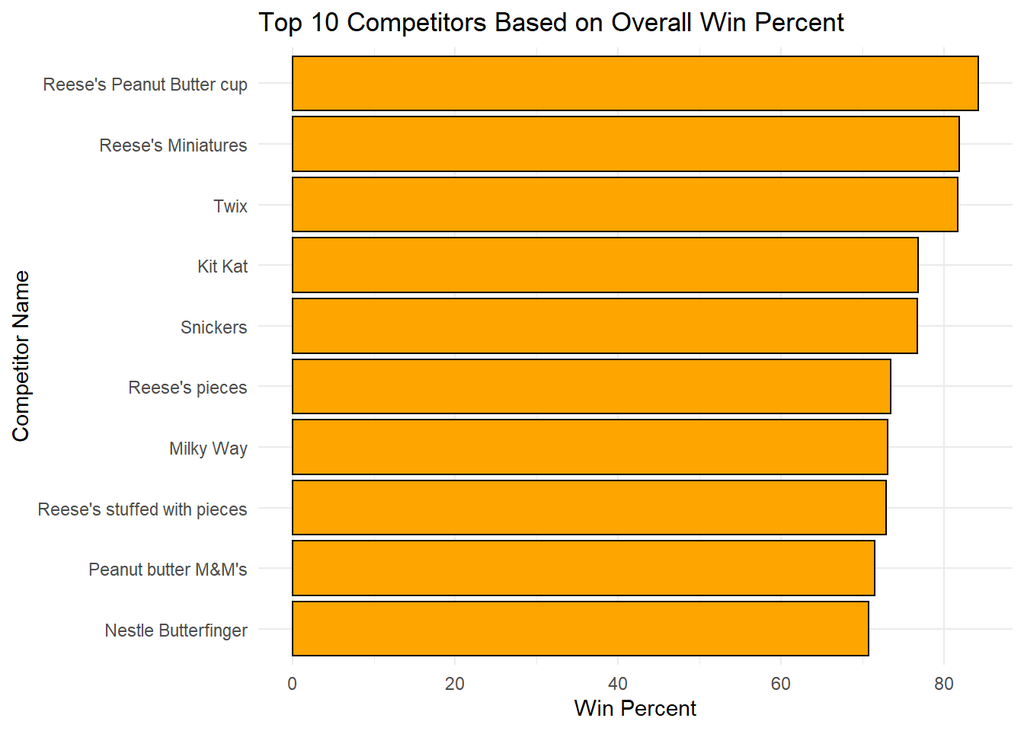

```r
# Reorder levels in ascending order
top_10_candies$competitorname <- factor(top_10_candies$competitorname, levels = unique(top_10_candies$competitorname))

# Create a bar plot
bar_plot <- ggplot(top_10_candies, aes(x = winpercent, y = reorder(competitorname, winpercent))) +
  geom_bar(stat = "identity", color = "black",fill = "orange") +
  labs(title = "Top 10 Competitors Based on Overall Win Percent",
       x = "Win Percent", y = "Competitor Name") +
  theme_minimal() +
  theme(legend.position = "none")  # Remove legend for better appearance

# Display the plot
print(bar_plot)
```

## chococlate Distribution

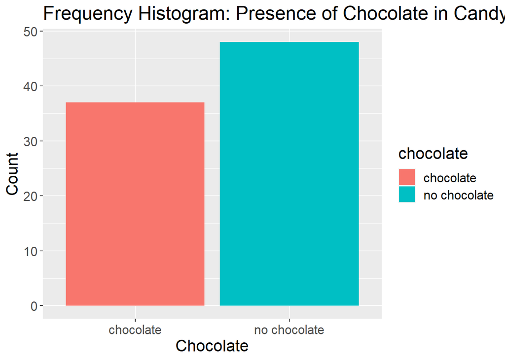

```r
chocolate_car <- candy %>%
                  ggplot(aes(x = chocolate, fill = chocolate)) +
                    geom_histogram(stat="count") +
                    theme(text = element_text(size = 16)) +
                    labs(title = "Frequency Histogram: Presence of Chocolate in Candy",
                         x = "Chocolate",
                         y = "Count")
 print(chocolate_car)
```

```r
# Berechnung der Pearson-Korrelation
chocolate_corr <- cor(candy_raw$chocolate, candy_raw$winpercent)
cat("Pearson-Korrelation:", round(chocolate_corr, 3), "\n")
```

```
## Pearson-Korrelation: 0.637
```

**Interpretation** The Graph Tell us that from the Candy sample, the majority never had Chocolate

##fruity Distribution

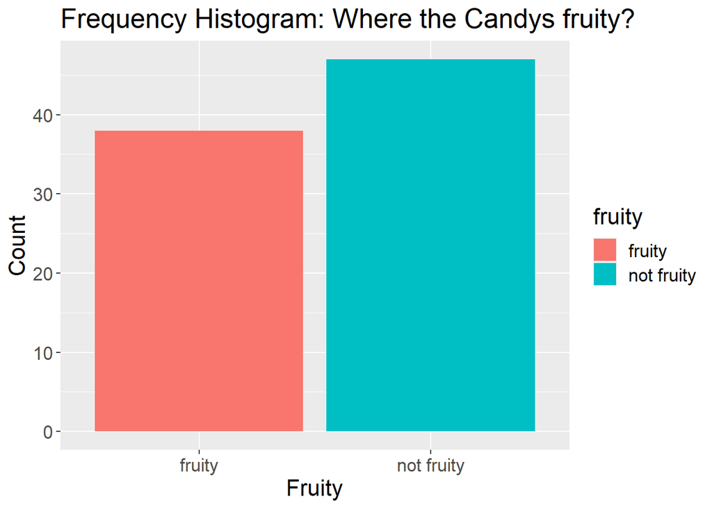

```r
fruity_car <- candy %>%
                ggplot(aes(x = fruity, fill = fruity)) +
                  geom_histogram(stat="count") +
                  theme(text = element_text(size = 16)) +
                  labs(title = "Frequency Histogram: Where the Candys fruity?",
                       x = "Fruity",
                       y = "Count")
print(fruity_car)
```

```r
# Berechnung der Pearson-Korrelation
fruity_corr <- cor(candy_raw$fruity, candy_raw$winpercent)
cat("Pearson-Korrelation:", round(fruity_corr, 3), "\n")
```

```
## Pearson-Korrelation: -0.381
```

**Interpretation** The Graph Tell us that from the Candy sample, the majority never not Fruity

##caramel Distribution

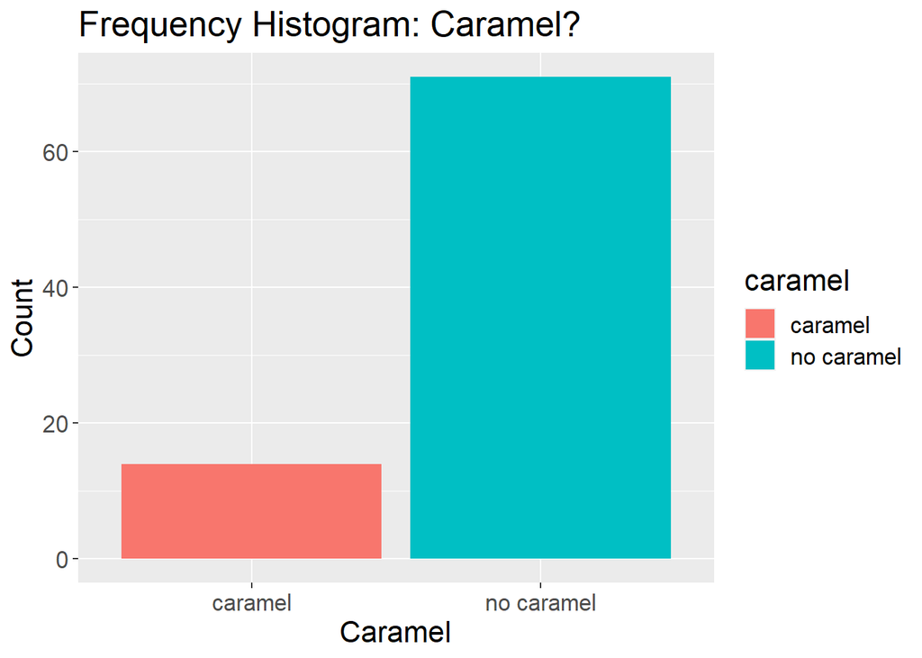

```r
caramel_car <- candy %>%
                ggplot(aes(x = caramel, fill = caramel)) +
                  geom_histogram(stat="count") +
                  theme(text = element_text(size = 16)) +
                  labs(title = "Frequency Histogram: Caramel?",
                       x = "Caramel",
                       y = "Count")
 print(caramel_car)
```

```r
# Berechnung der Pearson-Korrelation
caramel_corr <- cor(candy_raw$caramel, candy_raw$winpercent)
cat("Pearson-Korrelation:", round(caramel_corr, 3), "\n")
```

```
## Pearson-Korrelation: 0.213
```

**Interpretation** The Graph Tell us that from the Candy sample, the majority never had no Caramel

## Peanutyalmondy Distribution

[figure not shown]

```r
Peanutyalmondy_car <- candy %>%
                        ggplot(aes(x = peanutyalmondy, fill = peanutyalmondy)) +
                          geom_histogram(stat="count") +
                          theme(text = element_text(size = 16)) +
                          labs(title = "Frequency Histogram:Presence of Peanuts and Almonds",
                               x = "Chocolate",
                               y = "Count")
print(Peanutyalmondy_car)
```

```r
# Berechnung der Pearson-Korrelation
peanutyalmondy_corr <- cor(candy_raw$peanutyalmondy, candy_raw$winpercent)
cat("Pearson-Korrelation:", round(peanutyalmondy_corr, 3), "\n")
```

```
## Pearson-Korrelation: 0.406
```

**Interpretation** The Graph Tell us that from the Candy sample, the majority never had no Peanuts nor Nuts

##nougat Distribution

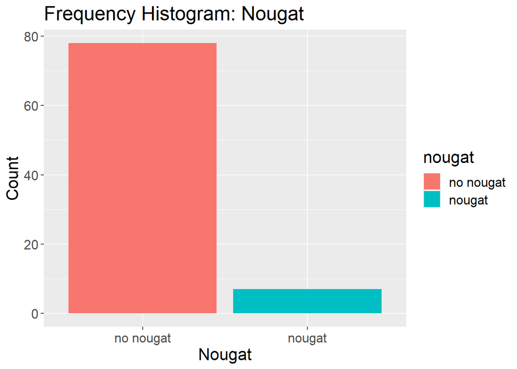

```r
nougat_car <- candy %>%
              ggplot(aes(x = nougat, fill = nougat)) +
                geom_histogram(stat="count") +
                theme(text = element_text(size = 16)) +
                labs(title = "Frequency Histogram: Nougat",
                     x = "Nougat",
                     y = "Count")
print(nougat_car)
```

```r
# Count the number of candies with and without nougat
nougat_counts <- table(candy$nougat)

# Calculate the percentages
percentage_with_nougat <- (nougat_counts["nougat"] / sum(nougat_counts)) * 100
percentage_without_nougat <- (nougat_counts["no nougat"] / sum(nougat_counts)) * 100

# Display the results
cat("Percentage of candies with nougat: ", round(percentage_with_nougat, 2), "%\n")
```

```
## Percentage of candies with nougat:  8.24 %
```

```r
cat("Percentage of candies without nougat: ", round(percentage_without_nougat, 2), "%\n")
```

```
## Percentage of candies without nougat:  91.76 %
```

```r
# Berechnung der Pearson-Korrelation
nougat_corr <- cor(candy_raw$nougat, candy_raw$winpercent)
cat("Pearson-Korrelation:", round(nougat_corr, 3), "\n")
```

```
## Pearson-Korrelation: 0.199
```

**Interpretation** The Graph Tell us that from the Candy sample, the majority never had no Nougats

##Crispedricewafer Distribution

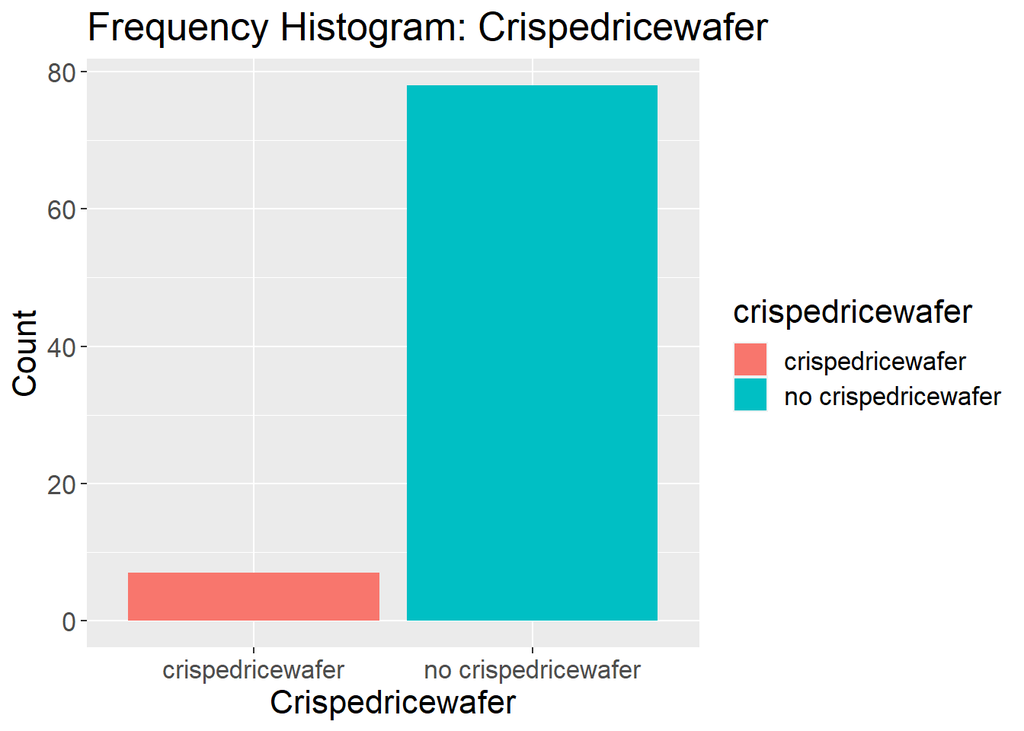

```r
Crispedricewafer_car <- candy %>%
                        ggplot(aes(x = crispedricewafer, fill = crispedricewafer)) +
                          geom_histogram(stat="count") +
                          theme(text = element_text(size = 16)) +
                          labs(title = "Frequency Histogram: Crispedricewafer",
                               x = "Crispedricewafer",
                               y = "Count")
print(Crispedricewafer_car)
```

[figure not shown]

```r
# Scatterplot erstellen
scatter_plot <- ggplot(candy_raw, aes(x = crispedricewafer, y = winpercent, color = crispedricewafer)) +
  geom_point() +  # Punktdiagramm erstellen
  geom_smooth(method = "lm", se = FALSE, color = "blue") + #Regressionline
  scale_color_gradient(low = "blue", high = "red") +  # Farbskala festlegen
  labs(title = "Scatterplot: Sugarpercent vs. Winpercent",
       x = "Sugarpercent",
       y = "Winpercent")

# Plot anzeigen
print(scatter_plot)
```

```r
# Zählen der Anzahl von Süßigkeiten mit und ohne crispedricewafer
crispedricewafer_counts <- table(candy$crispedricewafer)

# Berechnung der Prozentsätze
prozentsatz_mit_crispedricewafer <- (crispedricewafer_counts["crispedricewafer"] / sum(crispedricewafer_counts)) * 100
prozentsatz_ohne_crispedricewafer <- (crispedricewafer_counts["no crispedricewafer"] / sum(crispedricewafer_counts)) * 100

# Anzeige der Ergebnisse
cat("Prozentsatz der Süßigkeiten mit crispedricewafer: ", round(prozentsatz_mit_crispedricewafer, 2), "%\n")
```

```
## Prozentsatz der Süßigkeiten mit crispedricewafer:  8.24 %
```

```r
cat("Prozentsatz der Süßigkeiten ohne crispedricewafer: ", round(prozentsatz_ohne_crispedricewafer, 2), "%\n")
```

```
## Prozentsatz der Süßigkeiten ohne crispedricewafer:  91.76 %
```

```r
# Berechnung der Pearson-Korrelation
crispedricewafer_corr <- cor(candy_raw$crispedricewafer, candy_raw$winpercent)
cat("Pearson-Korrelation:", round(crispedricewafer_corr, 3), "\n")
```

```
## Pearson-Korrelation: 0.325
```

**Interpretation** The Graph Tell us that from the Candy sample, the majority never were not Crispy

##hard Distribution

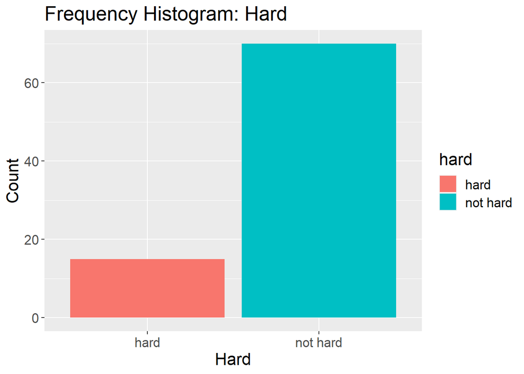

```r
hard_car <- candy %>%
            ggplot(aes(x = hard, fill = hard)) +
              geom_histogram(stat="count") +
              theme(text = element_text(size = 16)) +
              labs(title = "Frequency Histogram: Hard",
                   x = "Hard",
                   y = "Count")
print(hard_car)
```

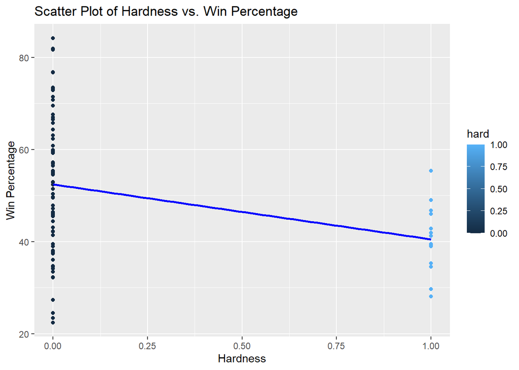

```r
# Erstelle den Scatterplot
ggplot(candy_raw, aes(x = hard, y = winpercent, colour = hard)) +
  geom_point() +
  geom_smooth(method = "lm", se = FALSE, color = "blue") + #Regressionline
  labs(title = "Scatter Plot of Hardness vs. Win Percentage",
       x = "Hardness",
       y = "Win Percentage")
```

```r
# Zählen der Anzahl von Süßigkeiten mit und ohne hard
hard_counts <- table(candy$hard)

# Berechnung der Prozentsätze
prozentsatz_mit_hard <- (hard_counts["hard"] / sum(hard_counts)) * 100
prozentsatz_ohne_hard <- (hard_counts["not hard"] / sum(hard_counts)) * 100

# Anzeige der Ergebnisse
cat("Prozentsatz der Süßigkeiten mit hard: ", round(prozentsatz_mit_hard, 2), "%\n")
```

```
## Prozentsatz der Süßigkeiten mit hard:  17.65 %
```

```r
cat("Prozentsatz der Süßigkeiten ohne hard: ", round(prozentsatz_ohne_hard, 2), "%\n")
```

```
## Prozentsatz der Süßigkeiten ohne hard:  82.35 %
```

```r
# Berechnung der Pearson-Korrelation
hard_corr <- cor(candy_raw$hard, candy_raw$winpercent)
cat("Pearson-Korrelation:", round(hard_corr, 3), "\n")
```

```
## Pearson-Korrelation: -0.31
```

**Interpretation** The Graph Tell us that from the Candy sample, the majority were not hard

##Bar Distribution

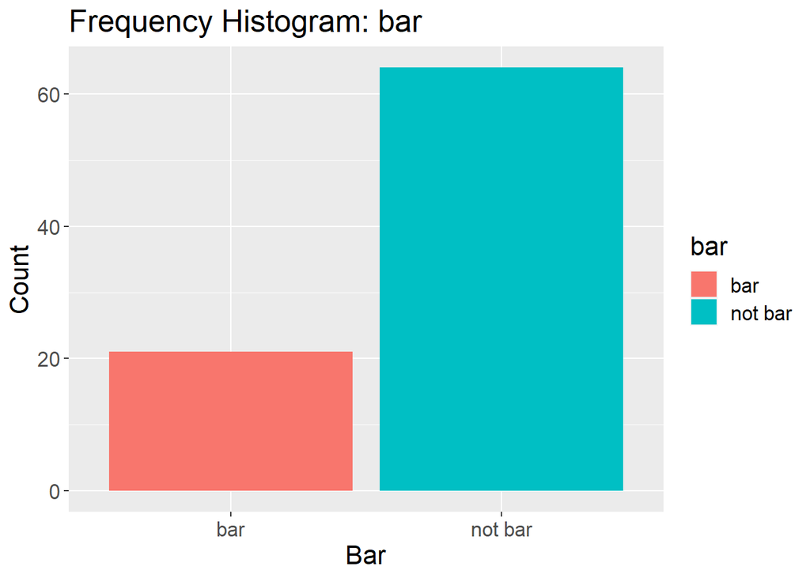

```r
bar_car <- candy %>%
            ggplot(aes(x = bar, fill = bar)) +
              geom_histogram(stat="count") +
              theme(text = element_text(size = 16)) +
              labs(title = "Frequency Histogram: bar",
                   x = "Bar",
                   y = "Count")
print(bar_car)
```

[figure not shown]

```r
# Erstelle den Scatterplot
ggplot(candy_raw, aes(x = bar, y = winpercent, colour = bar)) +
  geom_point() +
  geom_smooth(method = "lm", se = FALSE, color = "blue") + #Regressionline
  labs(title = "Scatter Plot of Hardness vs. Win Percentage",
       x = "Hardness",
       y = "Win Percentage")
```

```r
# Berechnung der Pearson-Korrelation
bar_corr <- cor(candy_raw$bar, candy_raw$winpercent)
cat("Pearson-Korrelation:", round(bar_corr, 3), "\n")
```

```
## Pearson-Korrelation: 0.43
```

**Interpretation** The Graph Tell us that from the Candy sample, the majority never not Bar

##Pluribus Distribution

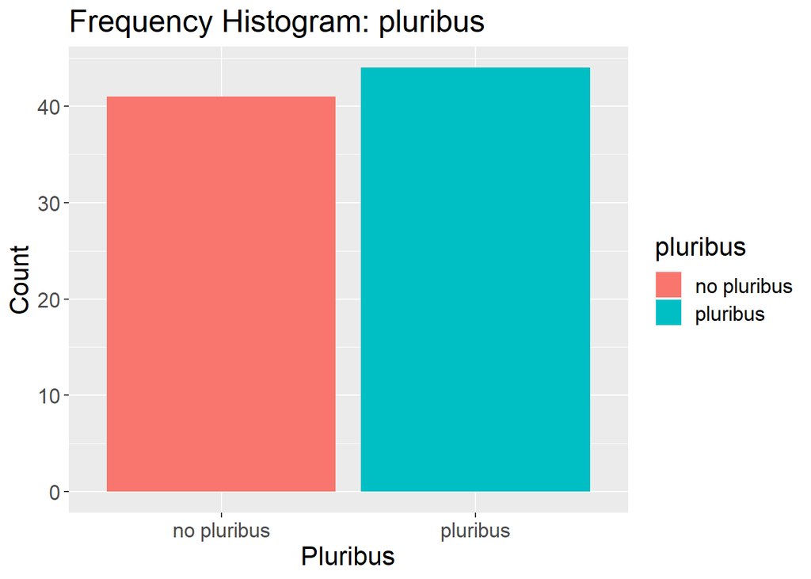

```r
pluribus_car <- candy %>%
                ggplot(aes(x = pluribus, fill = pluribus)) +
                  geom_histogram(stat="count") +
                  theme(text = element_text(size = 16)) +
                  labs(title = "Frequency Histogram: pluribus",
                       x = "Pluribus",
                       y = "Count")
print(pluribus_car)
```

[figure not shown]

```r
# Scatterplot erstellen
scatter_plot <- ggplot(candy_raw, aes(x = pluribus, y = winpercent, color = pluribus)) +
  geom_point() +  # Punktdiagramm erstellen
  geom_smooth(method = "lm", se = FALSE, color = "blue") + #Regressionline
  scale_color_gradient(low = "blue", high = "red") +  # Farbskala festlegen
  labs(title = "Scatterplot: Sugarpercent vs. Winpercent",
       x = "Sugarpercent",
       y = "Winpercent")

# Plot anzeigen
print(scatter_plot)
```

```r
# Berechnung der Pearson-Korrelation
pluribus_corr <- cor(candy_raw$pluribus, candy_raw$winpercent)
cat("Pearson-Korrelation:", round(pluribus_corr, 3), "\n")
```

```
## Pearson-Korrelation: -0.247
```

**Interpretation** The Graph Tell us that from the Candy sample, the ratio of Multi-pieces Candies to non-Multi-pieces Candies were almost the Same

##sugarpercent Distribution

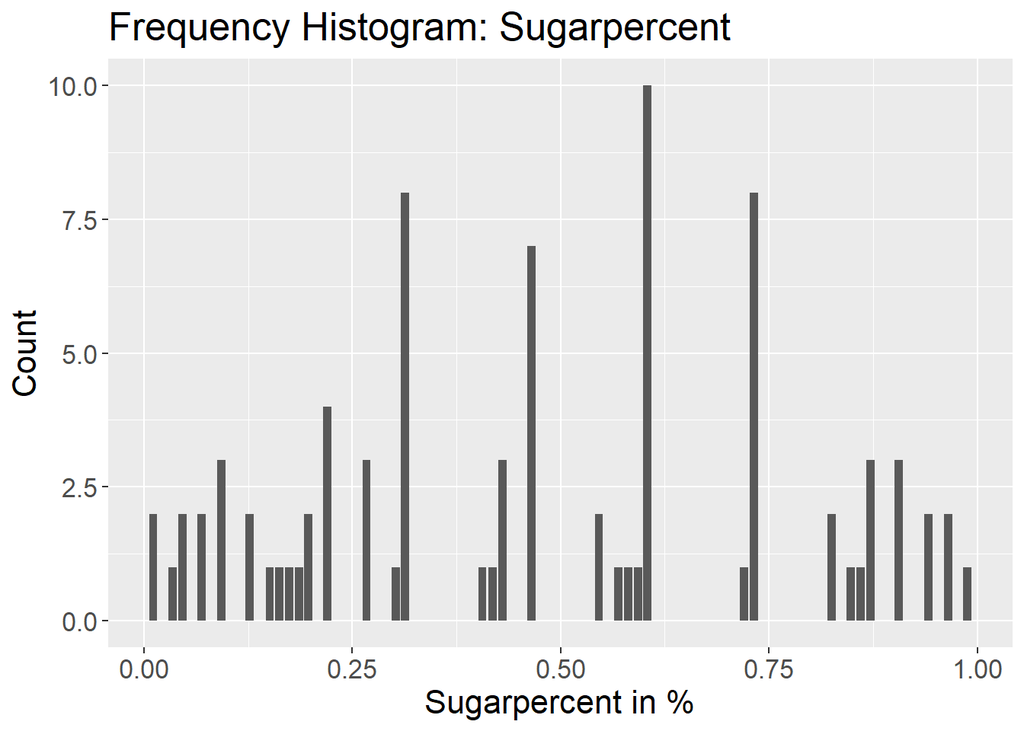

```r
sugar_car <- candy %>%
            ggplot(aes(x = sugarpercent, fill = sugarpercent)) +
              geom_histogram(stat="count") +
              theme(text = element_text(size = 16)) +
              labs(title = "Frequency Histogram: Sugarpercent",
                   x = "Sugarpercent in %",
                   y = "Count")
print(sugar_car)
```

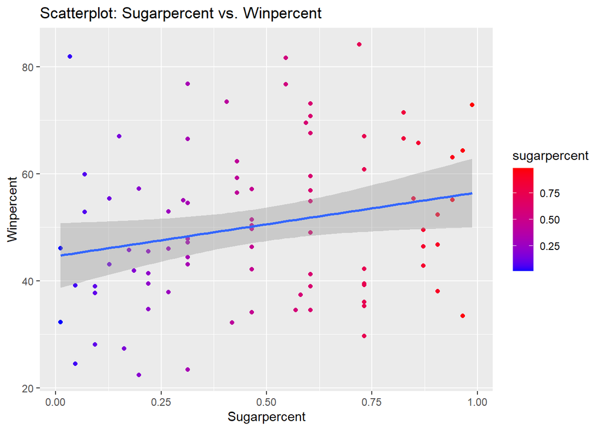

```r
# Scatterplot erstellen
scatter_plot <- ggplot(candy, aes(x = sugarpercent, y = winpercent, color = sugarpercent)) +
  geom_point() +  # Punktdiagramm erstellen
  geom_smooth(method = "lm") + #Regressionline
  scale_color_gradient(low = "blue", high = "red") +  # Farbskala festlegen
  labs(title = "Scatterplot: Sugarpercent vs. Winpercent",
       x = "Sugarpercent",
       y = "Winpercent")

# Plot anzeigen
print(scatter_plot)
```

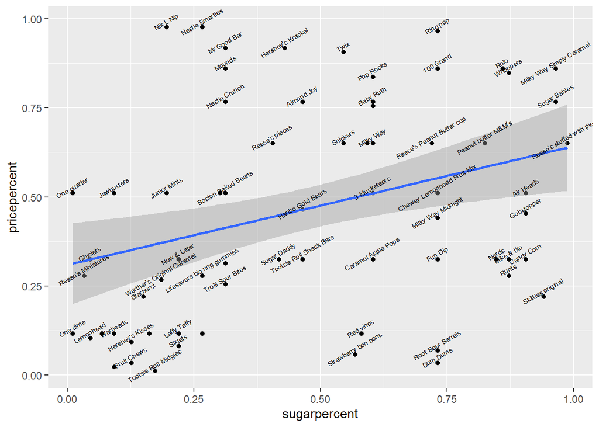

```r
# first we need to set up our plot
ggplot(data = candy_raw, aes(x = sugarpercent,
                                 y = pricepercent,
                                 label = competitorname)) +
    geom_point() + # then add a layer of points
    geom_smooth(method = "lm") + # and then add a fitted line
    geom_text(check_overlap = T,# automatically reduce overlap (deletes some labels)
              vjust = "bottom", # adjust the vertical orientation
              nudge_y = 0.01, # move the text up a bit so it doesn't touch the points
              angle = 30, # tilt the text 30 degrees
              size = 2 # make the text smaller (to reduce overlap more)
             )
```

```r
# Berechnung der Pearson-Korrelation
sugar_corr <- cor(candy$sugarpercent, candy$winpercent)
cat("Pearson-Korrelation:", round(sugar_corr, 3), "\n")
```

```
## Pearson-Korrelation: 0.229
```

**Interpretation** The Graph Tell us that from the Candy sample, was a positve Correlation between the Sugarpercent and Winpercent. That is an increase in the Sugar percentage in the Candies might likely lead to an increase in the Satisfaction of Customers.

##Pricepercent

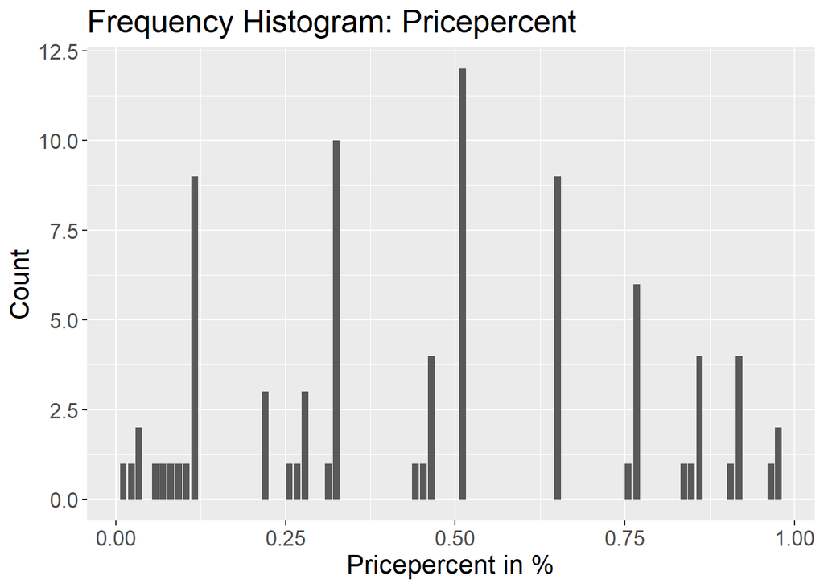

```r
price_car <- candy %>%
              ggplot(aes(x = pricepercent, fill = pricepercent)) +
                geom_histogram(stat="count") +
                theme(text = element_text(size = 16)) +
                labs(title = "Frequency Histogram: Pricepercent",
                     x = "Pricepercent in %",
                     y = "Count")
print(price_car)
```

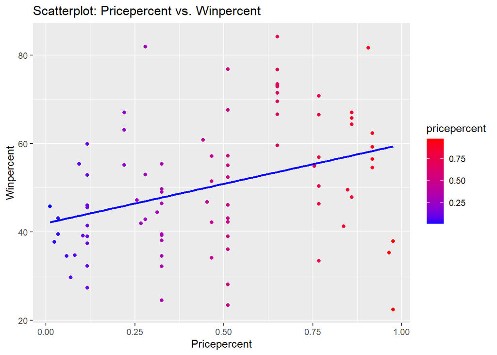

```r
# Scatterplot erstellen
scatter_plot <- ggplot(candy, aes(x = pricepercent, y = winpercent, color = pricepercent)) +
  geom_point() +  # Punktdiagramm erstellen
  geom_smooth(method = "lm", se = FALSE, color = "blue") + #Regressionline
  scale_color_gradient(low = "blue", high = "red") +  # Farbskala festlegen
  labs(title = "Scatterplot: Pricepercent vs. Winpercent",
       x = "Pricepercent",
       y = "Winpercent")

# Plot anzeigen
print(scatter_plot)
```

```r
pric_corr <- cor(candy$pricepercent, candy$winpercent)
cat("Korrelation zwischen Sugarpercent und Winpercent:",pric_corr, "\n")
```

[output not shown]

**Interpretation** The Graph Tell us that from the Candy sample, was a positve Correlation between the Pricepercent and Winpercent. That is an increase in the Price ratio in the Candies might likely lead to an increase in the Satisfaction of Customers.

##Plotting the Correlation Heapmap

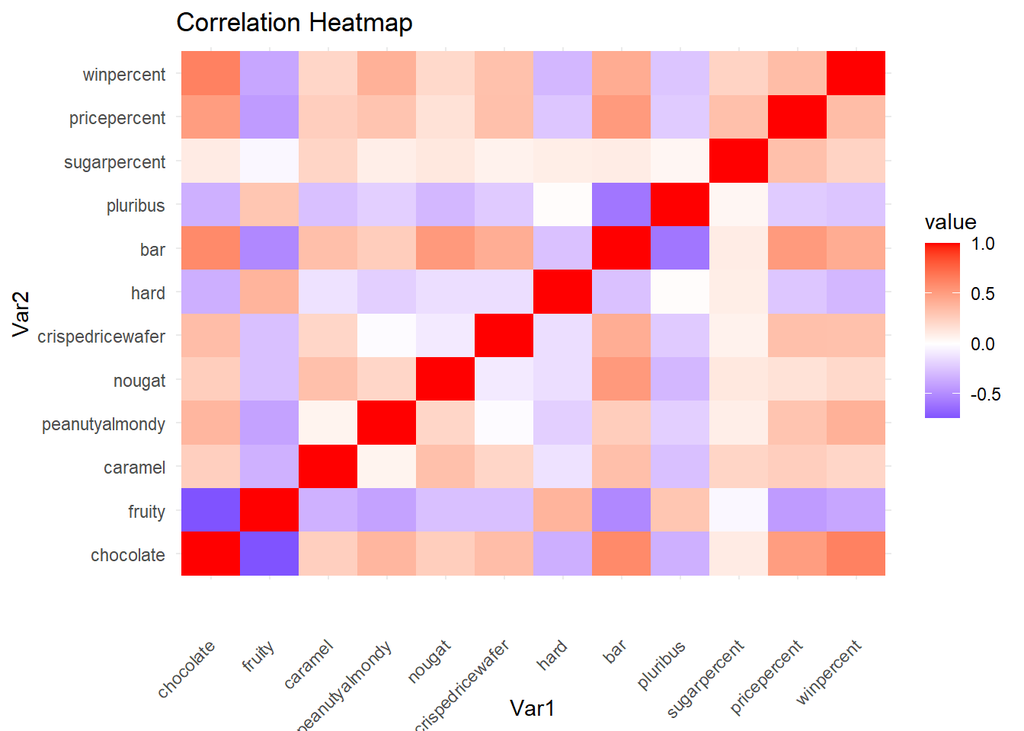

```r
# Calculate the correlation matrix for numeric columns
correlation_matrix <- cor(candy_raw %>% select_if(is.numeric))

# Create the correlation heatmap
heatmap_plot <- ggplot(data = melt(correlation_matrix), aes(Var1, Var2, fill = value)) +
  geom_tile() +
  scale_fill_gradient2(low = "blue", high = "red", mid = "white", midpoint = 0) +
  theme_minimal() +
  theme(axis.text.x = element_text(angle = 45, vjust = 0.5, hjust=1)) +
  labs(title = "Correlation Heatmap")

# Display the heatmap
print(heatmap_plot)
```

[figure not shown]

```r
# Group the dataset by competitorname and calculate the count
count_data <- top_10_candies %>%
  group_by(competitorname) %>%
  summarise(count = n())

# Sort the data by count in descending order
count_data <- count_data[order(-count_data$count), ]

# Plotting the pie chart
pie(count_data$count, labels = count_data$competitorname, main = "Composition of Highest-Ranked Competitor Name")

# Adding a legend
legend("topright", legend = count_data$competitorname, cex = 0.8, fill = rainbow(length(count_data$competitorname)))

# Adding a title
title(main = "Composition of Highest-Ranked Competitor Name")
```

```r
# Adjusting the aspect ratio of the plot
options(repr.plot.width = 8, repr.plot.height = 6)
```

##Ploting the Correlation Graph

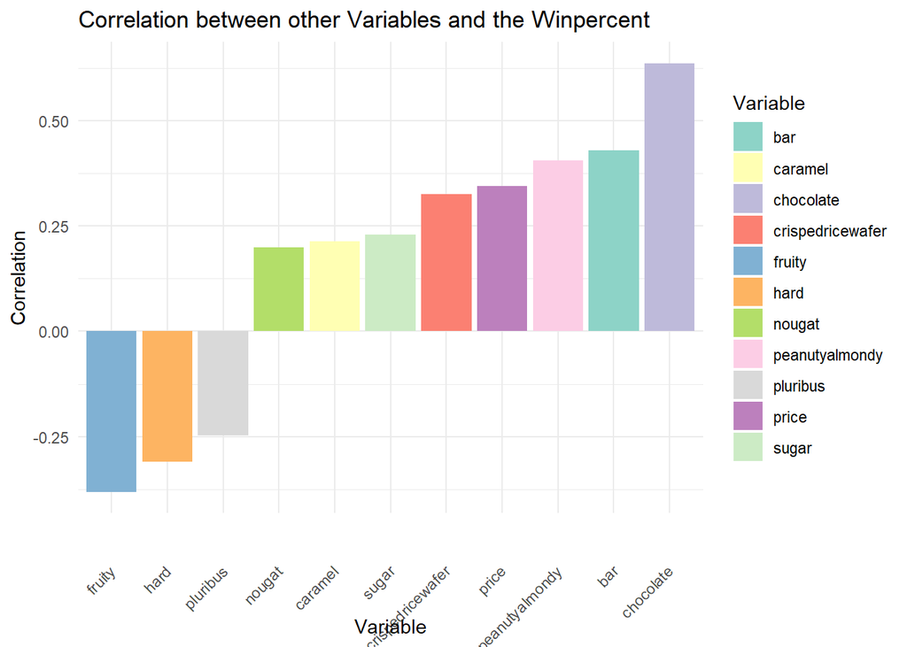

```r
# Create a dataframe from the correlation matrix

 x <- c(bar_corr, caramel_corr, chocolate_corr, crispedricewafer_corr, fruity_corr, hard_corr, nougat_corr, pluribus_corr, pric_corr, sugar_corr, peanutyalmondy_corr)

 variables <- c("bar", "caramel", "chocolate", "crispedricewafer", "fruity", "hard", "nougat", "pluribus", "price", "sugar", "peanutyalmondy")


# Create a tibble
correlation_tibble <- tibble(Variable = variables, Correlation = x)


# Create a colorful bar chart
bar_chart <- ggplot(correlation_tibble, aes(x = reorder(Variable, Correlation), y = Correlation, fill = Variable)) +
  geom_bar(stat = "identity") +
  labs(title = "Correlation between other Variables and the Winpercent",
       x = "Variable", y = "Correlation") +
  theme_minimal() +
  theme(axis.text.x = element_text(angle = 45, vjust = 0.5, hjust=1)) +
  scale_fill_brewer(palette = "Set3")  # You can choose a different palette

# Display the chart
print(bar_chart)
```

```r
# Fit a linear regression model
regression_model <- lm(winpercent ~ sugarpercent + chocolate, data = candy_raw)

# Print the summary of the regression model
summary(regression_model)
```

```
##
## Call:
## lm(formula = winpercent ~ sugarpercent + chocolate, data = candy_raw)
##
## Residuals:
##      Min       1Q   Median       3Q      Max
## -23.6981  -8.5153  -0.4489   7.7602  27.4820
##
## Coefficients:
##              Estimate Std. Error t value Pr(>|t|)
## (Intercept)    38.262      2.552  14.990  < 2e-16 ***
## sugarpercent    8.567      4.355   1.967   0.0525 .
## chocolate      18.273      2.469   7.401 1.06e-10 ***
## ---
## Signif. codes:  0 '***' 0.001 '**' 0.01 '*' 0.05 '.' 0.1 ' ' 1
##
## Residual standard error: 11.22 on 82 degrees of freedom
## Multiple R-squared:  0.432,  Adjusted R-squared:  0.4181
## F-statistic: 31.18 on 2 and 82 DF,  p-value: 8.5e-11
```

**interpretation** This is the output of a linear regression model:

# Residuals:

- The residuals (differences between the observed and predicted values) have a minimum of -23.6981, a maximum of 27.4820, and are centered around 0.